# Loan Data Analysis:A Comprehensive Predictive Modeling Study

Data Science & Linear Models Project

2026-04-07

# Introduction and Objectives

## Project Overview

This study uses a loan applicant dataset to demonstrate **predictive modeling** across two major tasks:

| Task | Goal | Target Variable |
| --- | --- | --- |
| **Regression** | Predict applicant income | `person_income` |
| **Classification** | Predict loan default | `loan_status` (0 = Default, 1 = Repaid) |

we performed **feature engineering**, **checking OLS assumptions** apply **transformations** and conducting a **credit-risk analysis** linking income, credit score and default behavior.

## Use Cases Addressed

1. **Income Prediction (Regression):** Train Linear Regression, Decision Tree, and Random Forest regressors; select the best model on test-set metrics.
2. **Assumption Checking & Transformation:** Verify linearity, normality, homoscedasticity, and multicollinearity for the linear model; apply log and sqrt transformations where needed.
3. **Loan Default Prediction (Classification):** Build Logistic Regression, Random Forest, and Decision Tree classifiers; evaluate with AUC-ROC due to class imbalance.
4. **Credit Risk Analysis:** Explore how income, credit score, and prior defaults interact to drive loan outcomes.
5. **Feature Engineering:** Create domain-informed variables (loan-to-credit ratio, high-risk flag, age-experience ratio, income brackets) to boost predictive power.

# Environment Setup

```r
libs <- c("tidyverse", "dplyr", "gridExtra", "ggplot2", "ggfortify", "broom",
          "ggcorrplot", "corrr", "corrplot", "MASS", "datarium", "randomForest",
          "rpart", "Hmisc", "caret", "Metrics", "car", "rpart.plot", "e1071", "pROC")

for (lib in libs) {
  if (!(lib %in% installed.packages())) install.packages(lib, quietly = TRUE)
  library(lib, character.only = TRUE)
}

# Resolve namespace conflicts
select    <- dplyr::select
mutate    <- dplyr::mutate
filter    <- dplyr::filter
summarise <- dplyr::summarise

theme_set(theme_classic())
```

## Load Dataset

```r
df <- read_csv("C:/Users/Light House/Desktop/MastersDSA/semThree-DSA/Linear Models/Data_Project/loan_data.csv", show_col_types = FALSE)
head(df)
```

```
## # A tibble: 6 × 14
##   person_age person_gender person_education person_income person_emp_exp
##        <dbl> <chr>         <chr>                    <dbl>          <dbl>
## 1         22 female        Master                   71948              0
## 2         21 female        High School              12282              0
## 3         25 female        High School              12438              3
## 4         23 female        Bachelor                 79753              0
## 5         24 male          Master                   66135              1
## 6         21 female        High School              12951              0
## # ℹ 9 more variables: person_home_ownership <chr>, loan_amnt <dbl>,
## #   loan_intent <chr>, loan_int_rate <dbl>, loan_percent_income <dbl>,
## #   cb_person_cred_hist_length <dbl>, credit_score <dbl>,
## #   previous_loan_defaults_on_file <chr>, loan_status <dbl>
```

# Data Understanding

## Structure & Summary Statistics

```r
as.data.frame(unclass(summary(df)))
```

```
##           person_age      person_gender   person_education     person_income
## X   Min.   : 20.00   Length:45000       Length:45000       Min.   :   8000
## X.1 1st Qu.: 24.00   Class :character   Class :character   1st Qu.:  47204
## X.2 Median : 26.00   Mode  :character   Mode  :character   Median :  67048
## X.3 Mean   : 27.76                 <NA>               <NA> Mean   :  80319
## X.4 3rd Qu.: 30.00                 <NA>               <NA> 3rd Qu.:  95789
## X.5 Max.   :144.00                 <NA>               <NA> Max.   :7200766
##       person_emp_exp person_home_ownership       loan_amnt        loan_intent
## X   Min.   :  0.00      Length:45000       Min.   :  500   Length:45000
## X.1 1st Qu.:  1.00      Class :character   1st Qu.: 5000   Class :character
## X.2 Median :  4.00      Mode  :character   Median : 8000   Mode  :character
## X.3 Mean   :  5.41                    <NA> Mean   : 9583                 <NA>
## X.4 3rd Qu.:  8.00                    <NA> 3rd Qu.:12237                 <NA>
## X.5 Max.   :125.00                    <NA> Max.   :35000                 <NA>
##       loan_int_rate loan_percent_income cb_person_cred_hist_length
## X   Min.   : 5.42      Min.   :0.0000             Min.   : 2.000
## X.1 1st Qu.: 8.59      1st Qu.:0.0700             1st Qu.: 3.000
## X.2 Median :11.01      Median :0.1200             Median : 4.000
## X.3 Mean   :11.01      Mean   :0.1397             Mean   : 5.867
## X.4 3rd Qu.:12.99      3rd Qu.:0.1900             3rd Qu.: 8.000
## X.5 Max.   :20.00      Max.   :0.6600             Max.   :30.000
##        credit_score previous_loan_defaults_on_file      loan_status
## X   Min.   :390.0               Length:45000       Min.   :0.0000
## X.1 1st Qu.:601.0               Class :character   1st Qu.:0.0000
## X.2 Median :640.0               Mode  :character   Median :0.0000
## X.3 Mean   :632.6                             <NA> Mean   :0.2222
## X.4 3rd Qu.:670.0                             <NA> 3rd Qu.:0.0000
## X.5 Max.   :850.0                             <NA> Max.   :1.0000
```

```r
str(df)
```

```
## spc_tbl_ [45,000 × 14] (S3: spec_tbl_df/tbl_df/tbl/data.frame)
##  $ person_age                    : num [1:45000] 22 21 25 23 24 21 26 24 24 21 ...
##  $ person_gender                 : chr [1:45000] "female" "female" "female" "female" ...
##  $ person_education              : chr [1:45000] "Master" "High School" "High School" "Bachelor" ...
##  $ person_income                 : num [1:45000] 71948 12282 12438 79753 66135 ...
##  $ person_emp_exp                : num [1:45000] 0 0 3 0 1 0 1 5 3 0 ...
##  $ person_home_ownership         : chr [1:45000] "RENT" "OWN" "MORTGAGE" "RENT" ...
##  $ loan_amnt                     : num [1:45000] 35000 1000 5500 35000 35000 2500 35000 35000 35000 1600 ...
##  $ loan_intent                   : chr [1:45000] "PERSONAL" "EDUCATION" "MEDICAL" "MEDICAL" ...
##  $ loan_int_rate                 : num [1:45000] 16 11.1 12.9 15.2 14.3 ...
##  $ loan_percent_income           : num [1:45000] 0.49 0.08 0.44 0.44 0.53 0.19 0.37 0.37 0.35 0.13 ...
##  $ cb_person_cred_hist_length    : num [1:45000] 3 2 3 2 4 2 3 4 2 3 ...
##  $ credit_score                  : num [1:45000] 561 504 635 675 586 532 701 585 544 640 ...
##  $ previous_loan_defaults_on_file: chr [1:45000] "No" "Yes" "No" "No" ...
##  $ loan_status                   : num [1:45000] 1 0 1 1 1 1 1 1 1 1 ...
##  - attr(*, "spec")=
##   .. cols(
##   ..   person_age = col_double(),
##   ..   person_gender = col_character(),
##   ..   person_education = col_character(),
##   ..   person_income = col_double(),
##   ..   person_emp_exp = col_double(),
##   ..   person_home_ownership = col_character(),
##   ..   loan_amnt = col_double(),
##   ..   loan_intent = col_character(),
##   ..   loan_int_rate = col_double(),
##   ..   loan_percent_income = col_double(),
##   ..   cb_person_cred_hist_length = col_double(),
##   ..   credit_score = col_double(),
##   ..   previous_loan_defaults_on_file = col_character(),
##   ..   loan_status = col_double()
##   .. )
##  - attr(*, "problems")=<externalptr>
```

**Key observations from the summary:**

- `person_age` peaks at 144, biologically implausible; outlier treatment required.
- `person_income` spans $8 000 to >$7.2 million,extreme right skew.
- `person_emp_exp` reaches 125 years,another impossible value.

## Missing Values & Duplicates

```r
missing_counts <- colSums(is.na(df))
cat("Missing values per column:\n"); print(missing_counts)
```

```
## Missing values per column:
```

```
##                     person_age                  person_gender
##                              0                              0
##               person_education                  person_income
##                              0                              0
##                 person_emp_exp          person_home_ownership
##                              0                              0
##                      loan_amnt                    loan_intent
##                              0                              0
##                  loan_int_rate            loan_percent_income
##                              0                              0
##     cb_person_cred_hist_length                   credit_score
##                              0                              0
## previous_loan_defaults_on_file                    loan_status
##                              0                              0
```

```r
cat("\nTotal missing values:", sum(missing_counts), "\n")
```

```
##
## Total missing values: 0
```

```r
n_dup <- sum(duplicated(df))
cat("Duplicate rows:", n_dup, "\n")
```

```
## Duplicate rows: 0
```

```r
if (n_dup > 0) {
  df <- df %>% distinct()
  cat("After deduplication:", nrow(df), "rows remain.\n")
}
```

**Result:** No missing values and no duplicates but implausible outliers still need handling.

# Exploratory Data Analysis (EDA)

## Univariate Analysis:Numeric Variables

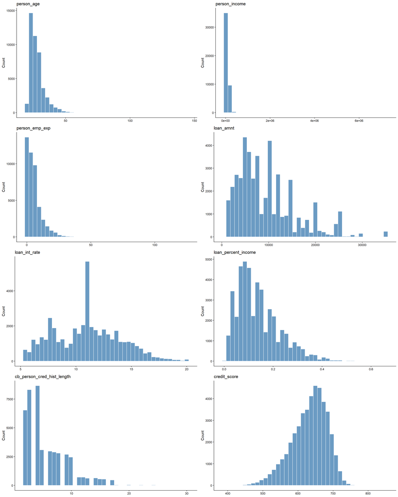

```r
numeric_vars <- c("person_age", "person_income", "person_emp_exp", "loan_amnt",
                  "loan_int_rate", "loan_percent_income",
                  "cb_person_cred_hist_length", "credit_score")

hist_plots <- lapply(numeric_vars, function(var) {
  ggplot(df, aes(x = .data[[var]])) +
    geom_histogram(bins = 40, fill = "steelblue", color = "white", alpha = 0.8) +
    labs(title = var, x = NULL, y = "Count")
})

do.call(grid.arrange, c(hist_plots, ncol = 2))
```

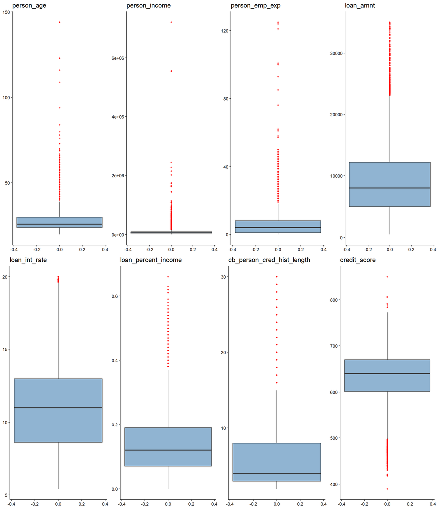

```r
box_plots <- lapply(numeric_vars, function(var) {
  ggplot(df, aes(y = .data[[var]])) +
    geom_boxplot(fill = "steelblue", alpha = 0.6, outlier.color = "red", outlier.size = 1) +
    labs(title = var, y = NULL)
})

do.call(grid.arrange, c(box_plots, ncol = 4))
```

**Observations:**

- `person_age` is right-skewed with extreme outliers above 80.
- `person_income` is heavily right-skewed a **log transformation** will be essential.
- `person_emp_exp` contains implausible values (e.g., 125 years).

## Univariate Analysis:Categorical Variables

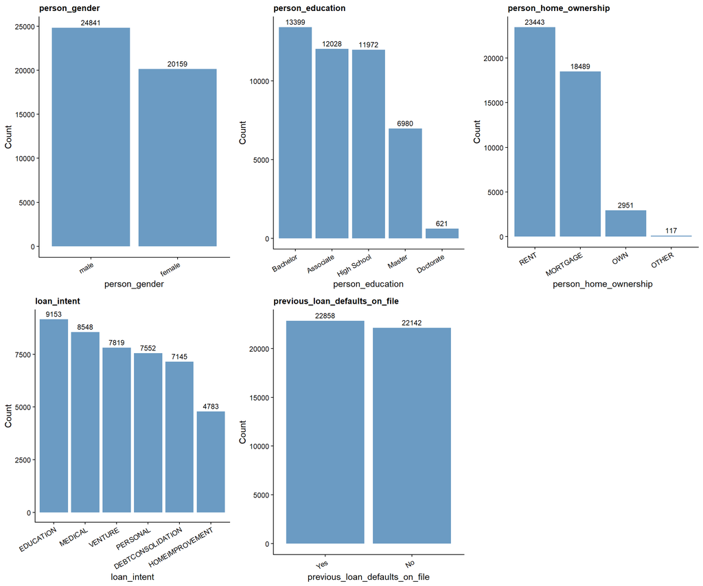

```r
cat_vars <- c("person_gender", "person_education", "person_home_ownership",
              "loan_intent", "previous_loan_defaults_on_file")

cat_plots <- lapply(cat_vars, function(var) {
  ggplot(df, aes(x = reorder(.data[[var]], .data[[var]], function(x) -length(x)))) +
    geom_bar(fill = "steelblue", alpha = 0.8) +
    geom_text(stat = "count", aes(label = after_stat(count)), vjust = -0.5, size = 3) +
    labs(title = var, x = var, y = "Count") +
    theme(axis.text.x = element_text(angle = 30, hjust = 1),
          plot.title = element_text(size = 10, face = "bold"))
})

do.call(grid.arrange, c(cat_plots, ncol = 3))
```

## Loan Status Variable Distribution

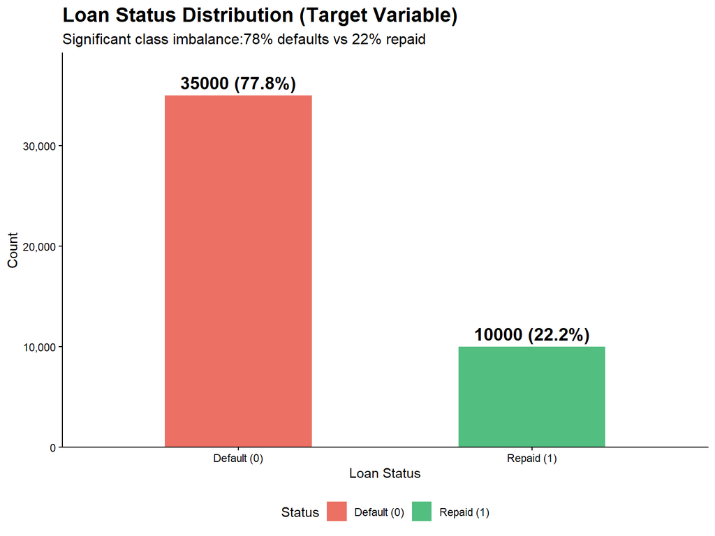

```r
ggplot(df, aes(x = factor(loan_status), fill = factor(loan_status))) +
  geom_bar(alpha = 0.8, width = 0.5) +
  geom_text(stat = "count",
            aes(label = paste0(after_stat(count),
                " (", round(after_stat(count) / nrow(df) * 100, 1), "%)")),
            vjust = -0.5, size = 5, fontface = "bold") +
  scale_fill_manual(values = c("0" = "#e74c3c", "1" = "#27ae60"),
                    labels = c("Default (0)", "Repaid (1)")) +
  scale_y_continuous(labels = scales::comma, expand = expansion(mult = c(0, 0.12))) +
  scale_x_discrete(labels = c("0" = "Default (0)", "1" = "Repaid (1)")) +
  labs(title = "Loan Status Distribution (Target Variable)",
       subtitle = "Significant class imbalance:78% defaults vs 22% repaid",
       x = "Loan Status", y = "Count", fill = "Status") +
  theme(plot.title = element_text(size = 16, face = "bold"),
        plot.subtitle = element_text(size = 12),
        legend.position = "bottom")
```

> **Important:** The 78/22 class imbalance means **accuracy alone is misleading**. We will also rely on **AUC-ROC** for classification evaluation.